# Explore Movie Dataset

## 探索电影数据集

在这个项目中，你将尝试使用所学的知识，使用 `NumPy`、`Pandas`、`matplotlib`、`seaborn` 库中的函数，来对电影数据集进行探索。

下载数据集： [TMDb电影数据](https://s3.cn-north-1.amazonaws.com.cn/static-documents/nd101/explore+dataset/tmdb-movies.csv)

数据集各列名称的含义：

| 列名称 | id | imdb_id | popularity | budget | revenue | original_title | cast | homepage | director | tagline | keywords | overview | runtime | genres | production_companies | release_date | vote_count | vote_average | release_year | budget_adj | revenue_adj |
| --- | --- | --- | --- | --- | --- | --- | --- | --- | --- | --- | --- | --- | --- | --- | --- | --- | --- | --- | --- | --- | --- |
| 含义 | 编号 | IMDB 编号 | 知名度 | 预算 | 票房 | 名称 | 主演 | 网站 | 导演 | 宣传词 | 关键词 | 简介 | 时常 | 类别 | 发行公司 | 发行日期 | 投票总数 | 投票均值 | 发行年份 | 预算（调整后） | 票房（调整后） |

**请注意，你需要提交该报告导出的 `.html`、`.ipynb` 以及 `.py` 文件。**

## 第一节 数据的导入与处理

在这一部分，你需要编写代码，使用 Pandas 读取数据，并进行预处理。

**任务1.1：** 导入库以及数据

1. 载入需要的库 `NumPy`、`Pandas`、`matplotlib`、`seaborn`。
2. 利用 `Pandas` 库，读取 `tmdb-movies.csv` 中的数据，保存为 `movie_data`。

提示：记得使用 notebook 中的魔法指令 `%matplotlib inline`，否则会导致你接下来无法打印出图像。

```python
import numpy as np
import pandas as pd
import matplotlib.pyplot as plt
import seaborn as sb
movie_data = pd.read_csv('./tmdb-movies.csv')
movie_data.head()
%matplotlib inline
```

**任务1.2:** 了解数据

你会接触到各种各样的数据表，因此在读取之后，我们有必要通过一些简单的方法，来了解我们数据表是什么样子的。

1. 获取数据表的行列，并打印。
2. 使用 `.head()`、`.tail()`、`.sample()` 方法，观察、了解数据表的情况。
3. 使用 `.dtypes` 属性，来查看各列数据的数据类型。
4. 使用 `isnull()` 配合 `.any()` 等方法，来查看各列是否存在空值。
5. 使用 `.describe()` 方法，看看数据表中数值型的数据是怎么分布的。

```python
print('The Dataframe has {} rows, {} columns.'.format(movie_data.shape[0],movie_data.shape[1]))
movie_data.head()
movie_data.tail()
movie_data.sample()
#movie_data.dtypes
#movie_data.isnull().any()
```

```
The Dataframe has 10866 rows, 21 columns.
```

|  | id | imdb_id | popularity | budget | revenue | original_title | cast | homepage | director | tagline | ... | overview | runtime | genres | production_companies | release_date | vote_count | vote_average | release_year | budget_adj | revenue_adj |
| --- | --- | --- | --- | --- | --- | --- | --- | --- | --- | --- | --- | --- | --- | --- | --- | --- | --- | --- | --- | --- | --- |
| 8363 | 2470 | tt0103791 | 0.128025 | 0 | 0 | Belle Époque | Penélope Cruz\|Gabino Diego\|Ariadna Gil\|Fernan... | NaN | Fernando Trueba | A sexy, lusty uninhibited comedy. | ... | In 1931, a young soldier deserts from the army... | 109 | Comedy\|Drama\|Foreign\|Romance | Sogepaq\|Animatógrafo\|Fernando Trueba Producci... | 12/4/92 | 13 | 6.9 | 1992 | 0.0 | 0.0 |

1 rows × 21 columns

**任务1.3:** 清理数据

在真实的工作场景中，数据处理往往是最为费时费力的环节。但是幸运的是，我们提供给大家的 tmdb 数据集非常的「干净」，不需要大家做特别多的数据清洗以及处理工作。在这一步中，你的核心的工作主要是对数据表中的空值进行处理。你可以使用 `.fillna()` 来填补空值，当然也可以使用 `.dropna()` 来丢弃数据表中包含空值的某些行或者列。

任务：使用适当的方法来清理空值，并将得到的数据保存。

```python
mvoie_data = movie_data.fillna(method = 'ffill',axis = 0,inplace = True)
movie_data.isnull().any()
movie_data.shape
```

```
(10866, 21)
```

## 第二节 根据指定要求读取数据

相比 Excel 等数据分析软件，Pandas 的一大特长在于，能够轻松地基于复杂的逻辑选择合适的数据。因此，如何根据指定的要求，从数据表当获取适当的数据，是使用 Pandas 中非常重要的技能，也是本节重点考察大家的内容。

**任务2.1:** 简单读取

1. 读取数据表中名为 `id`、`popularity`、`budget`、`runtime`、`vote_average` 列的数据。
2. 读取数据表中前1～20行以及48、49行的数据。
3. 读取数据表中第50～60行的 `popularity` 那一列的数据。

要求：每一个语句只能用一行代码实现。

```python
movie_data[['id','popularity','budget','runtime','vote_average']]


movie_data.iloc[0:20].append(movie_data.iloc[[48,49]])

movie_data.loc[50:60,['popularity']]
```

|  | popularity |
| --- | --- |
| 50 | 2.883233 |
| 51 | 2.814802 |
| 52 | 2.798017 |
| 53 | 2.793297 |
| 54 | 2.614499 |
| 55 | 2.584264 |
| 56 | 2.578919 |
| 57 | 2.575711 |
| 58 | 2.557859 |
| 59 | 2.550747 |
| 60 | 2.487849 |

**任务2.2:** 逻辑读取（Logical Indexing）

1. 读取数据表中 **`popularity` 大于5** 的所有数据。
2. 读取数据表中 **`popularity` 大于5** 的所有数据且**发行年份在1996年之后**的所有数据。

提示：Pandas 中的逻辑运算符如 `&`、`|`，分别代表`且`以及`或`。

要求：请使用 Logical Indexing实现。

```python
movie_data[movie_data['popularity']>5]
#movie_data[movie_data['popularity']>5].describe()
```

|  | id | imdb_id | popularity | budget | revenue | original_title | cast | homepage | director | tagline | ... | overview | runtime | genres | production_companies | release_date | vote_count | vote_average | release_year | budget_adj | revenue_adj |
| --- | --- | --- | --- | --- | --- | --- | --- | --- | --- | --- | --- | --- | --- | --- | --- | --- | --- | --- | --- | --- | --- |
| 0 | 135397 | tt0369610 | 32.985763 | 150000000 | 1513528810 | Jurassic World | Chris Pratt\|Bryce Dallas Howard\|Irrfan Khan\|Vi... | http://www.jurassicworld.com/ | Colin Trevorrow | The park is open. | ... | Twenty-two years after the events of Jurassic ... | 124 | Action\|Adventure\|Science Fiction\|Thriller | Universal Studios\|Amblin Entertainment\|Legenda... | 6/9/15 | 5562 | 6.5 | 2015 | 1.379999e+08 | 1.392446e+09 |
| 1 | 76341 | tt1392190 | 28.419936 | 150000000 | 378436354 | Mad Max: Fury Road | Tom Hardy\|Charlize Theron\|Hugh Keays-Byrne\|Nic... | http://www.madmaxmovie.com/ | George Miller | What a Lovely Day. | ... | An apocalyptic story set in the furthest reach... | 120 | Action\|Adventure\|Science Fiction\|Thriller | Village Roadshow Pictures\|Kennedy Miller Produ... | 5/13/15 | 6185 | 7.1 | 2015 | 1.379999e+08 | 3.481613e+08 |
| 2 | 262500 | tt2908446 | 13.112507 | 110000000 | 295238201 | Insurgent | Shailene Woodley\|Theo James\|Kate Winslet\|Ansel... | http://www.thedivergentseries.movie/#insurgent | Robert Schwentke | One Choice Can Destroy You | ... | Beatrice Prior must confront her inner demons ... | 119 | Adventure\|Science Fiction\|Thriller | Summit Entertainment\|Mandeville Films\|Red Wago... | 3/18/15 | 2480 | 6.3 | 2015 | 1.012000e+08 | 2.716190e+08 |
| 3 | 140607 | tt2488496 | 11.173104 | 200000000 | 2068178225 | Star Wars: The Force Awakens | Harrison Ford\|Mark Hamill\|Carrie Fisher\|Adam D... | http://www.starwars.com/films/star-wars-episod... | J.J. Abrams | Every generation has a story. | ... | Thirty years after defeating the Galactic Empi... | 136 | Action\|Adventure\|Science Fiction\|Fantasy | Lucasfilm\|Truenorth Productions\|Bad Robot | 12/15/15 | 5292 | 7.5 | 2015 | 1.839999e+08 | 1.902723e+09 |
| 4 | 168259 | tt2820852 | 9.335014 | 190000000 | 1506249360 | Furious 7 | Vin Diesel\|Paul Walker\|Jason Statham\|Michelle ... | http://www.furious7.com/ | James Wan | Vengeance Hits Home | ... | Deckard Shaw seeks revenge against Dominic Tor... | 137 | Action\|Crime\|Thriller | Universal Pictures\|Original Film\|Media Rights ... | 4/1/15 | 2947 | 7.3 | 2015 | 1.747999e+08 | 1.385749e+09 |
| 5 | 281957 | tt1663202 | 9.110700 | 135000000 | 532950503 | The Revenant | Leonardo DiCaprio\|Tom Hardy\|Will Poulter\|Domhn... | http://www.foxmovies.com/movies/the-revenant | Alejandro González Iñárritu | (n. One who has returned, as if from the dead.) | ... | In the 1820s, a frontiersman, Hugh Glass, sets... | 156 | Western\|Drama\|Adventure\|Thriller | Regency Enterprises\|Appian Way\|CatchPlay\|Anony... | 12/25/15 | 3929 | 7.2 | 2015 | 1.241999e+08 | 4.903142e+08 |
| 6 | 87101 | tt1340138 | 8.654359 | 155000000 | 440603537 | Terminator Genisys | Arnold Schwarzenegger\|Jason Clarke\|Emilia Clar... | http://www.terminatormovie.com/ | Alan Taylor | Reset the future | ... | The year is 2029. John Connor, leader of the r... | 125 | Science Fiction\|Action\|Thriller\|Adventure | Paramount Pictures\|Skydance Productions | 6/23/15 | 2598 | 5.8 | 2015 | 1.425999e+08 | 4.053551e+08 |
| 7 | 286217 | tt3659388 | 7.667400 | 108000000 | 595380321 | The Martian | Matt Damon\|Jessica Chastain\|Kristen Wiig\|Jeff ... | http://www.foxmovies.com/movies/the-martian | Ridley Scott | Bring Him Home | ... | During a manned mission to Mars, Astronaut Mar... | 141 | Drama\|Adventure\|Science Fiction | Twentieth Century Fox Film Corporation\|Scott F... | 9/30/15 | 4572 | 7.6 | 2015 | 9.935996e+07 | 5.477497e+08 |
| 8 | 211672 | tt2293640 | 7.404165 | 74000000 | 1156730962 | Minions | Sandra Bullock\|Jon Hamm\|Michael Keaton\|Allison... | http://www.minionsmovie.com/ | Kyle Balda\|Pierre Coffin | Before Gru, they had a history of bad bosses | ... | Minions Stuart, Kevin and Bob are recruited by... | 91 | Family\|Animation\|Adventure\|Comedy | Universal Pictures\|Illumination Entertainment | 6/17/15 | 2893 | 6.5 | 2015 | 6.807997e+07 | 1.064192e+09 |
| 9 | 150540 | tt2096673 | 6.326804 | 175000000 | 853708609 | Inside Out | Amy Poehler\|Phyllis Smith\|Richard Kind\|Bill Ha... | http://movies.disney.com/inside-out | Pete Docter | Meet the little voices inside your head. | ... | Growing up can be a bumpy road, and it's no ex... | 94 | Comedy\|Animation\|Family | Walt Disney Pictures\|Pixar Animation Studios\|W... | 6/9/15 | 3935 | 8.0 | 2015 | 1.609999e+08 | 7.854116e+08 |
| 10 | 206647 | tt2379713 | 6.200282 | 245000000 | 880674609 | Spectre | Daniel Craig\|Christoph Waltz\|Léa Seydoux\|Ralp... | http://www.sonypictures.com/movies/spectre/ | Sam Mendes | A Plan No One Escapes | ... | A cryptic message from Bond’s past sends him... | 148 | Action\|Adventure\|Crime | Columbia Pictures\|Danjaq\|B24 | 10/26/15 | 3254 | 6.2 | 2015 | 2.253999e+08 | 8.102203e+08 |
| 11 | 76757 | tt1617661 | 6.189369 | 176000003 | 183987723 | Jupiter Ascending | Mila Kunis\|Channing Tatum\|Sean Bean\|Eddie Redm... | http://www.jupiterascending.com | Lana Wachowski\|Lilly Wachowski | Expand your universe. | ... | In a universe where human genetic material is ... | 124 | Science Fiction\|Fantasy\|Action\|Adventure | Village Roadshow Pictures\|Dune Entertainment\|A... | 2/4/15 | 1937 | 5.2 | 2015 | 1.619199e+08 | 1.692686e+08 |
| 12 | 264660 | tt0470752 | 6.118847 | 15000000 | 36869414 | Ex Machina | Domhnall Gleeson\|Alicia Vikander\|Oscar Isaac\|S... | http://exmachina-movie.com/ | Alex Garland | There is nothing more human than the will to s... | ... | Caleb, a 26 year old coder at the world's larg... | 108 | Drama\|Science Fiction | DNA Films\|Universal Pictures International (UP... | 1/21/15 | 2854 | 7.6 | 2015 | 1.379999e+07 | 3.391985e+07 |
| 13 | 257344 | tt2120120 | 5.984995 | 88000000 | 243637091 | Pixels | Adam Sandler\|Michelle Monaghan\|Peter Dinklage\|... | http://www.pixels-movie.com/ | Chris Columbus | Game On. | ... | Video game experts are recruited by the milita... | 105 | Action\|Comedy\|Science Fiction | Columbia Pictures\|Happy Madison Productions | 7/16/15 | 1575 | 5.8 | 2015 | 8.095996e+07 | 2.241460e+08 |
| 14 | 99861 | tt2395427 | 5.944927 | 280000000 | 1405035767 | Avengers: Age of Ultron | Robert Downey Jr.\|Chris Hemsworth\|Mark Ruffalo... | http://marvel.com/movies/movie/193/avengers_ag... | Joss Whedon | A New Age Has Come. | ... | When Tony Stark tries to jumpstart a dormant p... | 141 | Action\|Adventure\|Science Fiction | Marvel Studios\|Prime Focus\|Revolution Sun Studios | 4/22/15 | 4304 | 7.4 | 2015 | 2.575999e+08 | 1.292632e+09 |
| 15 | 273248 | tt3460252 | 5.898400 | 44000000 | 155760117 | The Hateful Eight | Samuel L. Jackson\|Kurt Russell\|Jennifer Jason ... | http://thehatefuleight.com/ | Quentin Tarantino | No one comes up here without a damn good reason. | ... | Bounty hunters seek shelter from a raging bliz... | 167 | Crime\|Drama\|Mystery\|Western | Double Feature Films\|The Weinstein Company\|Fil... | 12/25/15 | 2389 | 7.4 | 2015 | 4.047998e+07 | 1.432992e+08 |
| 16 | 260346 | tt2446042 | 5.749758 | 48000000 | 325771424 | Taken 3 | Liam Neeson\|Forest Whitaker\|Maggie Grace\|Famke... | http://www.taken3movie.com/ | Olivier Megaton | It Ends Here | ... | Ex-government operative Bryan Mills finds his ... | 109 | Crime\|Action\|Thriller | Twentieth Century Fox Film Corporation\|M6 Film... | 1/1/15 | 1578 | 6.1 | 2015 | 4.415998e+07 | 2.997096e+08 |
| 17 | 102899 | tt0478970 | 5.573184 | 130000000 | 518602163 | Ant-Man | Paul Rudd\|Michael Douglas\|Evangeline Lilly\|Cor... | http://marvel.com/movies/movie/180/ant-man | Peyton Reed | Heroes Don't Get Any Bigger | ... | Armed with the astonishing ability to shrink i... | 115 | Science Fiction\|Action\|Adventure | Marvel Studios | 7/14/15 | 3779 | 7.0 | 2015 | 1.195999e+08 | 4.771138e+08 |
| 18 | 150689 | tt1661199 | 5.556818 | 95000000 | 542351353 | Cinderella | Lily James\|Cate Blanchett\|Richard Madden\|Helen... | http://marvel.com/movies/movie/180/ant-man | Kenneth Branagh | Midnight is just the beginning. | ... | When her father unexpectedly passes away, youn... | 112 | Romance\|Fantasy\|Family\|Drama | Walt Disney Pictures\|Genre Films\|Beagle Pug Fi... | 3/12/15 | 1495 | 6.8 | 2015 | 8.739996e+07 | 4.989630e+08 |
| 19 | 131634 | tt1951266 | 5.476958 | 160000000 | 650523427 | The Hunger Games: Mockingjay - Part 2 | Jennifer Lawrence\|Josh Hutcherson\|Liam Hemswor... | http://www.thehungergames.movie/ | Francis Lawrence | The fire will burn forever. | ... | With the nation of Panem in a full scale war, ... | 136 | War\|Adventure\|Science Fiction | Studio Babelsberg\|StudioCanal\|Lionsgate\|Walt D... | 11/18/15 | 2380 | 6.5 | 2015 | 1.471999e+08 | 5.984813e+08 |
| 20 | 158852 | tt1964418 | 5.462138 | 190000000 | 209035668 | Tomorrowland | Britt Robertson\|George Clooney\|Raffey Cassidy\|... | http://movies.disney.com/tomorrowland | Brad Bird | Imagine a world where nothing is impossible. | ... | Bound by a shared destiny, a bright, optimisti... | 130 | Action\|Family\|Science Fiction\|Adventure\|Mystery | Walt Disney Pictures\|Babieka\|A113 | 5/19/15 | 1899 | 6.2 | 2015 | 1.747999e+08 | 1.923127e+08 |
| 21 | 307081 | tt1798684 | 5.337064 | 30000000 | 91709827 | Southpaw | Jake Gyllenhaal\|Rachel McAdams\|Forest Whitaker... | http://movies.disney.com/tomorrowland | Antoine Fuqua | Believe in Hope. | ... | Billy "The Great" Hope, the reigning junior mi... | 123 | Action\|Drama | Escape Artists\|Riche-Ludwig Productions | 6/15/15 | 1386 | 7.3 | 2015 | 2.759999e+07 | 8.437300e+07 |
| 629 | 157336 | tt0816692 | 24.949134 | 165000000 | 621752480 | Interstellar | Matthew McConaughey\|Jessica Chastain\|Anne Hath... | http://www.interstellarmovie.net/ | Christopher Nolan | Mankind was born on Earth. It was never meant ... | ... | Interstellar chronicles the adventures of a gr... | 169 | Adventure\|Drama\|Science Fiction | Paramount Pictures\|Legendary Pictures\|Warner B... | 11/5/14 | 6498 | 8.0 | 2014 | 1.519800e+08 | 5.726906e+08 |
| 630 | 118340 | tt2015381 | 14.311205 | 170000000 | 773312399 | Guardians of the Galaxy | Chris Pratt\|Zoe Saldana\|Dave Bautista\|Vin Dies... | http://marvel.com/guardians | James Gunn | All heroes start somewhere. | ... | Light years from Earth, 26 years after being a... | 121 | Action\|Science Fiction\|Adventure | Marvel Studios\|Moving Picture Company (MPC)\|Bu... | 7/30/14 | 5612 | 7.9 | 2014 | 1.565855e+08 | 7.122911e+08 |
| 631 | 100402 | tt1843866 | 12.971027 | 170000000 | 714766572 | Captain America: The Winter Soldier | Chris Evans\|Scarlett Johansson\|Sebastian Stan\|... | http://www.captainamericathewintersoldiermovie... | Joe Russo\|Anthony Russo | In heroes we trust. | ... | After the cataclysmic events in New York with ... | 136 | Action\|Adventure\|Science Fiction | Marvel Studios | 3/20/14 | 3848 | 7.6 | 2014 | 1.565855e+08 | 6.583651e+08 |
| 632 | 245891 | tt2911666 | 11.422751 | 20000000 | 78739897 | John Wick | Keanu Reeves\|Michael Nyqvist\|Alfie Allen\|Wille... | http://www.johnwickthemovie.com/ | Chad Stahelski\|David Leitch | Don't set him off. | ... | After the sudden death of his beloved wife, Jo... | 101 | Action\|Thriller | Thunder Road Pictures\|Warner Bros.\|87Eleven\|De... | 10/22/14 | 2712 | 7.0 | 2014 | 1.842182e+07 | 7.252661e+07 |
| 633 | 131631 | tt1951265 | 10.739009 | 125000000 | 752100229 | The Hunger Games: Mockingjay - Part 1 | Jennifer Lawrence\|Josh Hutcherson\|Liam Hemswor... | http://www.thehungergames.movie/ | Francis Lawrence | Fire burns brighter in the darkness | ... | Katniss Everdeen reluctantly becomes the symbo... | 123 | Science Fiction\|Adventure\|Thriller | Lionsgate\|Color Force | 11/18/14 | 3590 | 6.6 | 2014 | 1.151364e+08 | 6.927528e+08 |
| 634 | 122917 | tt2310332 | 10.174599 | 250000000 | 955119788 | The Hobbit: The Battle of the Five Armies | Martin Freeman\|Ian McKellen\|Richard Armitage\|K... | http://www.thehobbit.com/ | Peter Jackson | Witness the defining chapter of the Middle-Ear... | ... | Immediately after the events of The Desolation... | 144 | Adventure\|Fantasy | WingNut Films\|New Line Cinema\|3Foot7\|Metro-Gol... | 12/10/14 | 3110 | 7.1 | 2014 | 2.302728e+08 | 8.797523e+08 |
| 635 | 177572 | tt2245084 | 8.691294 | 165000000 | 652105443 | Big Hero 6 | Scott Adsit\|Ryan Potter\|Daniel Henney\|T.J. Mil... | http://movies.disney.com/big-hero-6 | Don Hall\|Chris Williams | From the creators of Wreck-it Ralph and Frozen | ... | The special bond that develops between plus-si... | 102 | Adventure\|Family\|Animation\|Action\|Comedy | Walt Disney Pictures\|Walt Disney Animation Stu... | 10/24/14 | 4185 | 7.8 | 2014 | 1.519800e+08 | 6.006485e+08 |
| 636 | 205596 | tt2084970 | 8.110711 | 14000000 | 233555708 | The Imitation Game | Benedict Cumberbatch\|Keira Knightley\|Matthew G... | http://theimitationgamemovie.com/ | Morten Tyldum | The true enigma was the man who cracked the code. | ... | Based on the real life story of legendary cryp... | 113 | History\|Drama\|Thriller\|War | Black Bear Pictures\|Bristol Automotive | 11/14/14 | 3478 | 8.0 | 2014 | 1.289527e+07 | 2.151261e+08 |
| ... | ... | ... | ... | ... | ... | ... | ... | ... | ... | ... | ... | ... | ... | ... | ... | ... | ... | ... | ... | ... | ... |
| 2876 | 10681 | tt0910970 | 5.678119 | 180000000 | 521311860 | WALL·E | Ben Burtt\|Elissa Knight\|Jeff Garlin\|Fred Willa... | http://disney.go.com/disneypictures/wall-e/ | Andrew Stanton | An adventure beyond the ordinar-E. | ... | WALL·E is the last robot left on an Earth tha... | 98 | Animation\|Family | Walt Disney Pictures\|Pixar Animation Studios | 6/22/08 | 4209 | 7.6 | 2008 | 1.823016e+08 | 5.279777e+08 |
| 3371 | 161337 | tt2381375 | 8.411577 | 0 | 0 | Underworld: Endless War | Trevor Devall\|Brian Dobson\|Paul Dobson\|Laura H... | http://www.fueradecarta.com | Juno John Lee | The incredible true story of LeBron James and ... | ... | Underworld: Endless War is a collection of thr... | 18 | Action\|Animation\|Horror | TLA Releasing | 10/19/11 | 21 | 5.9 | 2011 | 0.000000e+00 | 0.000000e+00 |
| 3372 | 1771 | tt0458339 | 7.959228 | 140000000 | 370569774 | Captain America: The First Avenger | Chris Evans\|Hugo Weaving\|Tommy Lee Jones\|Hayle... | http://captainamerica.marvel.com/ | Joe Johnston | When patriots become heroes | ... | Predominantly set during World War II, Steve R... | 124 | Action\|Adventure\|Science Fiction | Marvel Studios | 7/22/11 | 5025 | 6.5 | 2011 | 1.357157e+08 | 3.592296e+08 |
| 3373 | 64690 | tt0780504 | 5.903353 | 15000000 | 76175166 | Drive | Ryan Gosling\|Carey Mulligan\|Christina Hendrick... | http://captainamerica.marvel.com/ | Nicolas Winding Refn | There are no clean getaways. | ... | A mysterious Hollywood stuntman who moonlights... | 100 | Drama\|Action\|Thriller\|Crime | Bold Films\|Marc Platt Productions\|Odd Lot Ente... | 1/10/11 | 2347 | 7.3 | 2011 | 1.454097e+07 | 7.384406e+07 |
| 3374 | 12445 | tt1201607 | 5.711315 | 125000000 | 1327817822 | Harry Potter and the Deathly Hallows: Part 2 | Daniel Radcliffe\|Rupert Grint\|Emma Watson\|Alan... | http://www.harrypotter.com | David Yates | It all ends here. | ... | Harry, Ron and Hermione continue their quest t... | 130 | Adventure\|Family\|Fantasy | Warner Bros.\|Heyday Films\|Moving Picture Compa... | 7/7/11 | 3750 | 7.7 | 2011 | 1.211748e+08 | 1.287184e+09 |
| 3911 | 121 | tt0167261 | 8.095275 | 79000000 | 926287400 | The Lord of the Rings: The Two Towers | Elijah Wood\|Ian McKellen\|Viggo Mortensen\|Liv T... | http://www.lordoftherings.net/ | Peter Jackson | A New Power Is Rising. | ... | Frodo and Sam are trekking to Mordor to destro... | 179 | Adventure\|Fantasy\|Action | WingNut Films\|New Line Cinema\|The Saul Zaentz ... | 12/18/02 | 5114 | 7.8 | 2002 | 9.576865e+07 | 1.122902e+09 |
| 3912 | 672 | tt0295297 | 6.012584 | 100000000 | 876688482 | Harry Potter and the Chamber of Secrets | Daniel Radcliffe\|Rupert Grint\|Emma Watson\|Kenn... | http://www.lordoftherings.net/ | Chris Columbus | Hogwarts is back in session. | ... | Ignoring threats to his life, Harry returns to... | 161 | Adventure\|Fantasy\|Family | 1492 Pictures\|Warner Bros.\|Heyday Films\|MIRACL... | 11/13/02 | 3458 | 7.2 | 2002 | 1.212261e+08 | 1.062776e+09 |
| 4177 | 680 | tt0110912 | 8.093754 | 8000000 | 213928762 | Pulp Fiction | John Travolta\|Samuel L. Jackson\|Uma Thurman\|Br... | http://www.kidstaysinthepicture.com/ | Quentin Tarantino | Just because you are a character doesn't mean ... | ... | A burger-loving hit man, his philosophical par... | 154 | Thriller\|Crime | Miramax Films\|A Band Apart\|Jersey Films | 10/14/94 | 5343 | 8.1 | 1994 | 1.176889e+07 | 3.147131e+08 |
| 4178 | 278 | tt0111161 | 7.192039 | 25000000 | 28341469 | The Shawshank Redemption | Tim Robbins\|Morgan Freeman\|Bob Gunton\|William ... | http://www.kidstaysinthepicture.com/ | Frank Darabont | Fear can hold you prisoner. Hope can set you f... | ... | Framed in the 1940s for the double murder of h... | 142 | Drama\|Crime | Castle Rock Entertainment | 9/10/94 | 5754 | 8.4 | 1994 | 3.677779e+07 | 4.169346e+07 |
| 4179 | 13 | tt0109830 | 6.715966 | 55000000 | 677945399 | Forrest Gump | Tom Hanks\|Robin Wright\|Gary Sinise\|Mykelti Wil... | http://www.kidstaysinthepicture.com/ | Robert Zemeckis | The world will never be the same, once you've ... | ... | A man with a low IQ has accomplished great thi... | 142 | Comedy\|Drama\|Romance | Paramount Pictures | 7/6/94 | 4856 | 8.1 | 1994 | 8.091114e+07 | 9.973333e+08 |
| 4361 | 24428 | tt0848228 | 7.637767 | 220000000 | 1519557910 | The Avengers | Robert Downey Jr.\|Chris Evans\|Mark Ruffalo\|Chr... | http://marvel.com/avengers_movie/ | Joss Whedon | Some assembly required. | ... | When an unexpected enemy emerges and threatens... | 143 | Science Fiction\|Action\|Adventure | Marvel Studios | 4/25/12 | 8903 | 7.3 | 2012 | 2.089437e+08 | 1.443191e+09 |
| 4362 | 52520 | tt1496025 | 7.031452 | 70000000 | 132400000 | Underworld: Awakening | Kate Beckinsale\|Stephen Rea\|Michael Ealy\|Theo ... | http://www.entertheunderworld.com/ | Måns Mårlind\|Björn Stein | Vengeance Returns | ... | After being held in a coma-like state for fift... | 88 | Fantasy\|Action\|Horror | Lakeshore Entertainment\|Saturn Films\|Screen Ge... | 1/19/12 | 1426 | 6.0 | 2012 | 6.648210e+07 | 1.257461e+08 |
| 4363 | 49026 | tt1345836 | 6.591277 | 250000000 | 1081041287 | The Dark Knight Rises | Christian Bale\|Michael Caine\|Gary Oldman\|Anne ... | http://www.thedarkknightrises.com/ | Christopher Nolan | The Legend Ends | ... | Following the death of District Attorney Harve... | 165 | Action\|Crime\|Drama\|Thriller | Legendary Pictures\|Warner Bros.\|DC Entertainme... | 7/16/12 | 6723 | 7.5 | 2012 | 2.374361e+08 | 1.026713e+09 |
| 4364 | 68718 | tt1853728 | 5.944518 | 100000000 | 425368238 | Django Unchained | Jamie Foxx\|Christoph Waltz\|Leonardo DiCaprio\|K... | http://unchainedmovie.com/ | Quentin Tarantino | Life, liberty and the pursuit of vengeance. | ... | With the help of a German bounty hunter, a fre... | 165 | Drama\|Western | Columbia Pictures\|The Weinstein Company | 12/25/12 | 7375 | 7.7 | 2012 | 9.497443e+07 | 4.039911e+08 |
| 4365 | 37724 | tt1074638 | 5.603587 | 200000000 | 1108561013 | Skyfall | Daniel Craig\|Judi Dench\|Javier Bardem\|Ralph Fi... | http://www.skyfall-movie.com | Sam Mendes | Think on your sins. | ... | When Bond's latest assignment goes gravely wro... | 143 | Action\|Adventure\|Thriller | Columbia Pictures | 10/25/12 | 6137 | 6.8 | 2012 | 1.899489e+08 | 1.052849e+09 |
| 4949 | 122 | tt0167260 | 7.122455 | 94000000 | 1118888979 | The Lord of the Rings: The Return of the King | Elijah Wood\|Ian McKellen\|Viggo Mortensen\|Liv T... | http://www.lordoftherings.net | Peter Jackson | The eye of the enemy is moving. | ... | Aragorn is revealed as the heir to the ancient... | 201 | Adventure\|Fantasy\|Action | WingNut Films\|New Line Cinema | 12/1/03 | 5636 | 7.9 | 2003 | 1.114231e+08 | 1.326278e+09 |
| 4950 | 277 | tt0320691 | 6.887883 | 22000000 | 95708457 | Underworld | Kate Beckinsale\|Scott Speedman\|Michael Sheen\|S... | http://www.sonypictures.com/movies/underworld/... | Len Wiseman | An immortal battle for supremacy. | ... | Vampires and werewolves have waged a nocturnal... | 121 | Fantasy\|Action\|Thriller | Lakeshore Entertainment\|Laurinfilm\|Subterranea... | 9/19/03 | 1708 | 6.5 | 2003 | 2.607776e+07 | 1.134483e+08 |
| 4951 | 22 | tt0325980 | 6.864067 | 140000000 | 655011224 | Pirates of the Caribbean: The Curse of the Bla... | Johnny Depp\|Geoffrey Rush\|Orlando Bloom\|Keira ... | http://disney.go.com/disneyvideos/liveaction/p... | Gore Verbinski | Prepare to be blown out of the water. | ... | Jack Sparrow, a freewheeling 17th-century pira... | 143 | Adventure\|Fantasy\|Action | Walt Disney Pictures\|Jerry Bruckheimer Films | 7/9/03 | 4223 | 7.3 | 2003 | 1.659494e+08 | 7.764193e+08 |
| 4952 | 24 | tt0266697 | 6.174132 | 30000000 | 180949000 | Kill Bill: Vol. 1 | Uma Thurman\|Lucy Liu\|Vivica A. Fox\|Daryl Hanna... | http://www.miramax.com/movie/kill-bill-volume-1/ | Quentin Tarantino | Go for the kill. | ... | An assassin is shot at the altar by her ruthle... | 111 | Action\|Crime | Miramax Films\|A Band Apart\|Super Cool ManChu | 10/10/03 | 2932 | 7.6 | 2003 | 3.556058e+07 | 2.144884e+08 |
| 5230 | 13590 | tt0195753 | 6.668990 | 0 | 0 | Eddie Izzard: Glorious | Eddie Izzard\|Mac McDonald\|Rhona Mitra | http://www.theroommovie.com/ | Peter Richardson | Can you ever really trust anyone? | ... | Eddie Izzard's routine has a loose trajectory ... | 99 | Comedy | BLT Productions | 11/17/97 | 11 | 5.5 | 1997 | 0.000000e+00 | 0.000000e+00 |
| 5422 | 109445 | tt2294629 | 6.112766 | 150000000 | 1274219009 | Frozen | Kristen Bell\|Idina Menzel\|Jonathan Groff\|Josh ... | http://movies.disney.com/frozen | Chris Buck\|Jennifer Lee | Only the act of true love will thaw a frozen h... | ... | Young princess Anna of Arendelle dreams about ... | 102 | Animation\|Adventure\|Family | Walt Disney Pictures\|Walt Disney Animation Stu... | 11/27/13 | 3369 | 7.5 | 2013 | 1.404050e+08 | 1.192711e+09 |
| 5423 | 49047 | tt1454468 | 5.242753 | 105000000 | 716392705 | Gravity | Sandra Bullock\|George Clooney\|Ed Harris\|Orto I... | http://gravitymovie.warnerbros.com/ | Alfonso Cuarón | Don't Let Go | ... | Dr. Ryan Stone (Sandra Bullock), a brilliant m... | 91 | Science Fiction\|Thriller\|Drama | Warner Bros.\|Heyday Films\|Esperanto Filmoj | 9/27/13 | 3775 | 7.4 | 2013 | 9.828350e+07 | 6.705675e+08 |
| 5424 | 76338 | tt1981115 | 5.111900 | 170000000 | 479765000 | Thor: The Dark World | Chris Hemsworth\|Natalie Portman\|Tom Hiddleston... | http://marvel.com/thor | Alan Taylor | Delve into the darkness | ... | Thor fights to restore order across the cosmos... | 112 | Action\|Adventure\|Fantasy | Marvel Studios | 10/29/13 | 3025 | 6.8 | 2013 | 1.591257e+08 | 4.490760e+08 |
| 6081 | 105 | tt0088763 | 6.095293 | 19000000 | 381109762 | Back to the Future | Michael J. Fox\|Christopher Lloyd\|Lea Thompson\|... | http://www.backtothefuture.com/movies/backtoth... | Robert Zemeckis | He's the only kid ever to get into trouble bef... | ... | Eighties teenager Marty McFly is accidentally ... | 116 | Adventure\|Comedy\|Science Fiction\|Family | Universal Pictures\|Amblin Entertainment\|U-Driv... | 7/3/85 | 3785 | 7.8 | 1985 | 3.851615e+07 | 7.725728e+08 |
| 6190 | 674 | tt0330373 | 5.939927 | 150000000 | 895921036 | Harry Potter and the Goblet of Fire | Daniel Radcliffe\|Rupert Grint\|Emma Watson\|Ralp... | http://harrypotter.warnerbros.com/ | Mike Newell | Dark And Difficult Times Lie Ahead. | ... | Harry starts his fourth year at Hogwarts, comp... | 157 | Adventure\|Fantasy\|Family | Patalex IV Productions Limited\|Warner Bros.\|He... | 11/5/05 | 3406 | 7.3 | 2005 | 1.674845e+08 | 1.000353e+09 |
| 6191 | 272 | tt0372784 | 5.400826 | 150000000 | 374218673 | Batman Begins | Christian Bale\|Michael Caine\|Liam Neeson\|Katie... | http://www2.warnerbros.com/batmanbegins/index.... | Christopher Nolan | Evil fears the knight. | ... | Driven by tragedy, billionaire Bruce Wayne ded... | 140 | Action\|Crime\|Drama | DC Comics\|Legendary Pictures\|Warner Bros.\|DC E... | 6/14/05 | 4914 | 7.3 | 2005 | 1.674845e+08 | 4.178388e+08 |
| 6554 | 834 | tt0401855 | 5.838503 | 50000000 | 111340801 | Underworld: Evolution | Kate Beckinsale\|Scott Speedman\|Tony Curran\|Sha... | http://www.sonypictures.com/movies/underworlda... | Len Wiseman | My God. Brother, what have you done? | ... | As the war between the vampires and the Lycans... | 106 | Fantasy\|Action\|Science Fiction\|Thriller | Lakeshore Entertainment\|Screen Gems | 1/12/06 | 1015 | 6.3 | 2006 | 5.408346e+07 | 1.204339e+08 |
| 6962 | 673 | tt0304141 | 5.827781 | 130000000 | 789804554 | Harry Potter and the Prisoner of Azkaban | Daniel Radcliffe\|Rupert Grint\|Emma Watson\|Gary... | http://thezodiacfilm.com/ | Alfonso Cuarón | Something wicked this way comes. | ... | Harry, Ron and Hermione return to Hogwarts for... | 141 | Adventure\|Fantasy\|Family | 1492 Pictures\|Warner Bros.\|Heyday Films\|P of A... | 5/31/04 | 3550 | 7.4 | 2004 | 1.500779e+08 | 9.117862e+08 |
| 7269 | 238 | tt0068646 | 5.738034 | 6000000 | 245066411 | The Godfather | Marlon Brando\|Al Pacino\|James Caan\|Richard S. ... | http://www.thegodfather.com/ | Francis Ford Coppola | An offer you can't refuse. | ... | Spanning the years 1945 to 1955, a chronicle o... | 175 | Drama\|Crime | Paramount Pictures\|Alfran Productions | 3/15/72 | 3970 | 8.3 | 1972 | 3.128737e+07 | 1.277914e+09 |
| 7309 | 1891 | tt0080684 | 5.488441 | 18000000 | 538400000 | The Empire Strikes Back | Mark Hamill\|Harrison Ford\|Carrie Fisher\|Billy ... | http://www.starwars.com/films/star-wars-episod... | Irvin Kershner | The Adventure Continues... | ... | The epic saga continues as Luke Skywalker, in ... | 124 | Adventure\|Action\|Science Fiction | Lucasfilm\|Twentieth Century Fox Film Corporation | 1/1/80 | 3954 | 8.0 | 1980 | 4.762866e+07 | 1.424626e+09 |

85 rows × 21 columns

```python
movie_data[(movie_data['popularity']>5) & (movie_data['release_year'] > 1996)]
#movie_data[(movie_data['popularity']>5) & (movie_data['release_year'] > 1996)].describe()
```

|  | id | imdb_id | popularity | budget | revenue | original_title | cast | homepage | director | tagline | ... | overview | runtime | genres | production_companies | release_date | vote_count | vote_average | release_year | budget_adj | revenue_adj |
| --- | --- | --- | --- | --- | --- | --- | --- | --- | --- | --- | --- | --- | --- | --- | --- | --- | --- | --- | --- | --- | --- |
| 0 | 135397 | tt0369610 | 32.985763 | 150000000 | 1513528810 | Jurassic World | Chris Pratt\|Bryce Dallas Howard\|Irrfan Khan\|Vi... | http://www.jurassicworld.com/ | Colin Trevorrow | The park is open. | ... | Twenty-two years after the events of Jurassic ... | 124 | Action\|Adventure\|Science Fiction\|Thriller | Universal Studios\|Amblin Entertainment\|Legenda... | 6/9/15 | 5562 | 6.5 | 2015 | 1.379999e+08 | 1.392446e+09 |
| 1 | 76341 | tt1392190 | 28.419936 | 150000000 | 378436354 | Mad Max: Fury Road | Tom Hardy\|Charlize Theron\|Hugh Keays-Byrne\|Nic... | http://www.madmaxmovie.com/ | George Miller | What a Lovely Day. | ... | An apocalyptic story set in the furthest reach... | 120 | Action\|Adventure\|Science Fiction\|Thriller | Village Roadshow Pictures\|Kennedy Miller Produ... | 5/13/15 | 6185 | 7.1 | 2015 | 1.379999e+08 | 3.481613e+08 |
| 2 | 262500 | tt2908446 | 13.112507 | 110000000 | 295238201 | Insurgent | Shailene Woodley\|Theo James\|Kate Winslet\|Ansel... | http://www.thedivergentseries.movie/#insurgent | Robert Schwentke | One Choice Can Destroy You | ... | Beatrice Prior must confront her inner demons ... | 119 | Adventure\|Science Fiction\|Thriller | Summit Entertainment\|Mandeville Films\|Red Wago... | 3/18/15 | 2480 | 6.3 | 2015 | 1.012000e+08 | 2.716190e+08 |
| 3 | 140607 | tt2488496 | 11.173104 | 200000000 | 2068178225 | Star Wars: The Force Awakens | Harrison Ford\|Mark Hamill\|Carrie Fisher\|Adam D... | http://www.starwars.com/films/star-wars-episod... | J.J. Abrams | Every generation has a story. | ... | Thirty years after defeating the Galactic Empi... | 136 | Action\|Adventure\|Science Fiction\|Fantasy | Lucasfilm\|Truenorth Productions\|Bad Robot | 12/15/15 | 5292 | 7.5 | 2015 | 1.839999e+08 | 1.902723e+09 |
| 4 | 168259 | tt2820852 | 9.335014 | 190000000 | 1506249360 | Furious 7 | Vin Diesel\|Paul Walker\|Jason Statham\|Michelle ... | http://www.furious7.com/ | James Wan | Vengeance Hits Home | ... | Deckard Shaw seeks revenge against Dominic Tor... | 137 | Action\|Crime\|Thriller | Universal Pictures\|Original Film\|Media Rights ... | 4/1/15 | 2947 | 7.3 | 2015 | 1.747999e+08 | 1.385749e+09 |
| 5 | 281957 | tt1663202 | 9.110700 | 135000000 | 532950503 | The Revenant | Leonardo DiCaprio\|Tom Hardy\|Will Poulter\|Domhn... | http://www.foxmovies.com/movies/the-revenant | Alejandro González Iñárritu | (n. One who has returned, as if from the dead.) | ... | In the 1820s, a frontiersman, Hugh Glass, sets... | 156 | Western\|Drama\|Adventure\|Thriller | Regency Enterprises\|Appian Way\|CatchPlay\|Anony... | 12/25/15 | 3929 | 7.2 | 2015 | 1.241999e+08 | 4.903142e+08 |
| 6 | 87101 | tt1340138 | 8.654359 | 155000000 | 440603537 | Terminator Genisys | Arnold Schwarzenegger\|Jason Clarke\|Emilia Clar... | http://www.terminatormovie.com/ | Alan Taylor | Reset the future | ... | The year is 2029. John Connor, leader of the r... | 125 | Science Fiction\|Action\|Thriller\|Adventure | Paramount Pictures\|Skydance Productions | 6/23/15 | 2598 | 5.8 | 2015 | 1.425999e+08 | 4.053551e+08 |
| 7 | 286217 | tt3659388 | 7.667400 | 108000000 | 595380321 | The Martian | Matt Damon\|Jessica Chastain\|Kristen Wiig\|Jeff ... | http://www.foxmovies.com/movies/the-martian | Ridley Scott | Bring Him Home | ... | During a manned mission to Mars, Astronaut Mar... | 141 | Drama\|Adventure\|Science Fiction | Twentieth Century Fox Film Corporation\|Scott F... | 9/30/15 | 4572 | 7.6 | 2015 | 9.935996e+07 | 5.477497e+08 |
| 8 | 211672 | tt2293640 | 7.404165 | 74000000 | 1156730962 | Minions | Sandra Bullock\|Jon Hamm\|Michael Keaton\|Allison... | http://www.minionsmovie.com/ | Kyle Balda\|Pierre Coffin | Before Gru, they had a history of bad bosses | ... | Minions Stuart, Kevin and Bob are recruited by... | 91 | Family\|Animation\|Adventure\|Comedy | Universal Pictures\|Illumination Entertainment | 6/17/15 | 2893 | 6.5 | 2015 | 6.807997e+07 | 1.064192e+09 |
| 9 | 150540 | tt2096673 | 6.326804 | 175000000 | 853708609 | Inside Out | Amy Poehler\|Phyllis Smith\|Richard Kind\|Bill Ha... | http://movies.disney.com/inside-out | Pete Docter | Meet the little voices inside your head. | ... | Growing up can be a bumpy road, and it's no ex... | 94 | Comedy\|Animation\|Family | Walt Disney Pictures\|Pixar Animation Studios\|W... | 6/9/15 | 3935 | 8.0 | 2015 | 1.609999e+08 | 7.854116e+08 |
| 10 | 206647 | tt2379713 | 6.200282 | 245000000 | 880674609 | Spectre | Daniel Craig\|Christoph Waltz\|Léa Seydoux\|Ralp... | http://www.sonypictures.com/movies/spectre/ | Sam Mendes | A Plan No One Escapes | ... | A cryptic message from Bond’s past sends him... | 148 | Action\|Adventure\|Crime | Columbia Pictures\|Danjaq\|B24 | 10/26/15 | 3254 | 6.2 | 2015 | 2.253999e+08 | 8.102203e+08 |
| 11 | 76757 | tt1617661 | 6.189369 | 176000003 | 183987723 | Jupiter Ascending | Mila Kunis\|Channing Tatum\|Sean Bean\|Eddie Redm... | http://www.jupiterascending.com | Lana Wachowski\|Lilly Wachowski | Expand your universe. | ... | In a universe where human genetic material is ... | 124 | Science Fiction\|Fantasy\|Action\|Adventure | Village Roadshow Pictures\|Dune Entertainment\|A... | 2/4/15 | 1937 | 5.2 | 2015 | 1.619199e+08 | 1.692686e+08 |
| 12 | 264660 | tt0470752 | 6.118847 | 15000000 | 36869414 | Ex Machina | Domhnall Gleeson\|Alicia Vikander\|Oscar Isaac\|S... | http://exmachina-movie.com/ | Alex Garland | There is nothing more human than the will to s... | ... | Caleb, a 26 year old coder at the world's larg... | 108 | Drama\|Science Fiction | DNA Films\|Universal Pictures International (UP... | 1/21/15 | 2854 | 7.6 | 2015 | 1.379999e+07 | 3.391985e+07 |
| 13 | 257344 | tt2120120 | 5.984995 | 88000000 | 243637091 | Pixels | Adam Sandler\|Michelle Monaghan\|Peter Dinklage\|... | http://www.pixels-movie.com/ | Chris Columbus | Game On. | ... | Video game experts are recruited by the milita... | 105 | Action\|Comedy\|Science Fiction | Columbia Pictures\|Happy Madison Productions | 7/16/15 | 1575 | 5.8 | 2015 | 8.095996e+07 | 2.241460e+08 |
| 14 | 99861 | tt2395427 | 5.944927 | 280000000 | 1405035767 | Avengers: Age of Ultron | Robert Downey Jr.\|Chris Hemsworth\|Mark Ruffalo... | http://marvel.com/movies/movie/193/avengers_ag... | Joss Whedon | A New Age Has Come. | ... | When Tony Stark tries to jumpstart a dormant p... | 141 | Action\|Adventure\|Science Fiction | Marvel Studios\|Prime Focus\|Revolution Sun Studios | 4/22/15 | 4304 | 7.4 | 2015 | 2.575999e+08 | 1.292632e+09 |
| 15 | 273248 | tt3460252 | 5.898400 | 44000000 | 155760117 | The Hateful Eight | Samuel L. Jackson\|Kurt Russell\|Jennifer Jason ... | http://thehatefuleight.com/ | Quentin Tarantino | No one comes up here without a damn good reason. | ... | Bounty hunters seek shelter from a raging bliz... | 167 | Crime\|Drama\|Mystery\|Western | Double Feature Films\|The Weinstein Company\|Fil... | 12/25/15 | 2389 | 7.4 | 2015 | 4.047998e+07 | 1.432992e+08 |
| 16 | 260346 | tt2446042 | 5.749758 | 48000000 | 325771424 | Taken 3 | Liam Neeson\|Forest Whitaker\|Maggie Grace\|Famke... | http://www.taken3movie.com/ | Olivier Megaton | It Ends Here | ... | Ex-government operative Bryan Mills finds his ... | 109 | Crime\|Action\|Thriller | Twentieth Century Fox Film Corporation\|M6 Film... | 1/1/15 | 1578 | 6.1 | 2015 | 4.415998e+07 | 2.997096e+08 |
| 17 | 102899 | tt0478970 | 5.573184 | 130000000 | 518602163 | Ant-Man | Paul Rudd\|Michael Douglas\|Evangeline Lilly\|Cor... | http://marvel.com/movies/movie/180/ant-man | Peyton Reed | Heroes Don't Get Any Bigger | ... | Armed with the astonishing ability to shrink i... | 115 | Science Fiction\|Action\|Adventure | Marvel Studios | 7/14/15 | 3779 | 7.0 | 2015 | 1.195999e+08 | 4.771138e+08 |
| 18 | 150689 | tt1661199 | 5.556818 | 95000000 | 542351353 | Cinderella | Lily James\|Cate Blanchett\|Richard Madden\|Helen... | http://marvel.com/movies/movie/180/ant-man | Kenneth Branagh | Midnight is just the beginning. | ... | When her father unexpectedly passes away, youn... | 112 | Romance\|Fantasy\|Family\|Drama | Walt Disney Pictures\|Genre Films\|Beagle Pug Fi... | 3/12/15 | 1495 | 6.8 | 2015 | 8.739996e+07 | 4.989630e+08 |
| 19 | 131634 | tt1951266 | 5.476958 | 160000000 | 650523427 | The Hunger Games: Mockingjay - Part 2 | Jennifer Lawrence\|Josh Hutcherson\|Liam Hemswor... | http://www.thehungergames.movie/ | Francis Lawrence | The fire will burn forever. | ... | With the nation of Panem in a full scale war, ... | 136 | War\|Adventure\|Science Fiction | Studio Babelsberg\|StudioCanal\|Lionsgate\|Walt D... | 11/18/15 | 2380 | 6.5 | 2015 | 1.471999e+08 | 5.984813e+08 |
| 20 | 158852 | tt1964418 | 5.462138 | 190000000 | 209035668 | Tomorrowland | Britt Robertson\|George Clooney\|Raffey Cassidy\|... | http://movies.disney.com/tomorrowland | Brad Bird | Imagine a world where nothing is impossible. | ... | Bound by a shared destiny, a bright, optimisti... | 130 | Action\|Family\|Science Fiction\|Adventure\|Mystery | Walt Disney Pictures\|Babieka\|A113 | 5/19/15 | 1899 | 6.2 | 2015 | 1.747999e+08 | 1.923127e+08 |
| 21 | 307081 | tt1798684 | 5.337064 | 30000000 | 91709827 | Southpaw | Jake Gyllenhaal\|Rachel McAdams\|Forest Whitaker... | http://movies.disney.com/tomorrowland | Antoine Fuqua | Believe in Hope. | ... | Billy "The Great" Hope, the reigning junior mi... | 123 | Action\|Drama | Escape Artists\|Riche-Ludwig Productions | 6/15/15 | 1386 | 7.3 | 2015 | 2.759999e+07 | 8.437300e+07 |
| 629 | 157336 | tt0816692 | 24.949134 | 165000000 | 621752480 | Interstellar | Matthew McConaughey\|Jessica Chastain\|Anne Hath... | http://www.interstellarmovie.net/ | Christopher Nolan | Mankind was born on Earth. It was never meant ... | ... | Interstellar chronicles the adventures of a gr... | 169 | Adventure\|Drama\|Science Fiction | Paramount Pictures\|Legendary Pictures\|Warner B... | 11/5/14 | 6498 | 8.0 | 2014 | 1.519800e+08 | 5.726906e+08 |
| 630 | 118340 | tt2015381 | 14.311205 | 170000000 | 773312399 | Guardians of the Galaxy | Chris Pratt\|Zoe Saldana\|Dave Bautista\|Vin Dies... | http://marvel.com/guardians | James Gunn | All heroes start somewhere. | ... | Light years from Earth, 26 years after being a... | 121 | Action\|Science Fiction\|Adventure | Marvel Studios\|Moving Picture Company (MPC)\|Bu... | 7/30/14 | 5612 | 7.9 | 2014 | 1.565855e+08 | 7.122911e+08 |
| 631 | 100402 | tt1843866 | 12.971027 | 170000000 | 714766572 | Captain America: The Winter Soldier | Chris Evans\|Scarlett Johansson\|Sebastian Stan\|... | http://www.captainamericathewintersoldiermovie... | Joe Russo\|Anthony Russo | In heroes we trust. | ... | After the cataclysmic events in New York with ... | 136 | Action\|Adventure\|Science Fiction | Marvel Studios | 3/20/14 | 3848 | 7.6 | 2014 | 1.565855e+08 | 6.583651e+08 |
| 632 | 245891 | tt2911666 | 11.422751 | 20000000 | 78739897 | John Wick | Keanu Reeves\|Michael Nyqvist\|Alfie Allen\|Wille... | http://www.johnwickthemovie.com/ | Chad Stahelski\|David Leitch | Don't set him off. | ... | After the sudden death of his beloved wife, Jo... | 101 | Action\|Thriller | Thunder Road Pictures\|Warner Bros.\|87Eleven\|De... | 10/22/14 | 2712 | 7.0 | 2014 | 1.842182e+07 | 7.252661e+07 |
| 633 | 131631 | tt1951265 | 10.739009 | 125000000 | 752100229 | The Hunger Games: Mockingjay - Part 1 | Jennifer Lawrence\|Josh Hutcherson\|Liam Hemswor... | http://www.thehungergames.movie/ | Francis Lawrence | Fire burns brighter in the darkness | ... | Katniss Everdeen reluctantly becomes the symbo... | 123 | Science Fiction\|Adventure\|Thriller | Lionsgate\|Color Force | 11/18/14 | 3590 | 6.6 | 2014 | 1.151364e+08 | 6.927528e+08 |
| 634 | 122917 | tt2310332 | 10.174599 | 250000000 | 955119788 | The Hobbit: The Battle of the Five Armies | Martin Freeman\|Ian McKellen\|Richard Armitage\|K... | http://www.thehobbit.com/ | Peter Jackson | Witness the defining chapter of the Middle-Ear... | ... | Immediately after the events of The Desolation... | 144 | Adventure\|Fantasy | WingNut Films\|New Line Cinema\|3Foot7\|Metro-Gol... | 12/10/14 | 3110 | 7.1 | 2014 | 2.302728e+08 | 8.797523e+08 |
| 635 | 177572 | tt2245084 | 8.691294 | 165000000 | 652105443 | Big Hero 6 | Scott Adsit\|Ryan Potter\|Daniel Henney\|T.J. Mil... | http://movies.disney.com/big-hero-6 | Don Hall\|Chris Williams | From the creators of Wreck-it Ralph and Frozen | ... | The special bond that develops between plus-si... | 102 | Adventure\|Family\|Animation\|Action\|Comedy | Walt Disney Pictures\|Walt Disney Animation Stu... | 10/24/14 | 4185 | 7.8 | 2014 | 1.519800e+08 | 6.006485e+08 |
| 636 | 205596 | tt2084970 | 8.110711 | 14000000 | 233555708 | The Imitation Game | Benedict Cumberbatch\|Keira Knightley\|Matthew G... | http://theimitationgamemovie.com/ | Morten Tyldum | The true enigma was the man who cracked the code. | ... | Based on the real life story of legendary cryp... | 113 | History\|Drama\|Thriller\|War | Black Bear Pictures\|Bristol Automotive | 11/14/14 | 3478 | 8.0 | 2014 | 1.289527e+07 | 2.151261e+08 |
| ... | ... | ... | ... | ... | ... | ... | ... | ... | ... | ... | ... | ... | ... | ... | ... | ... | ... | ... | ... | ... | ... |
| 1922 | 44214 | tt0947798 | 5.293180 | 13000000 | 327803731 | Black Swan | Natalie Portman\|Mila Kunis\|Vincent Cassel\|Barb... | http://www.foxsearchlight.com/blackswan/ | Darren Aronofsky | In the era of personal branding, the scariest ... | ... | A ballet dancer wins the lead in "Swan Lake" a... | 108 | Drama\|Mystery\|Thriller | Fox Searchlight Pictures\|Dune Entertainment\|Pr... | 12/2/10 | 2597 | 7.1 | 2010 | 1.300000e+07 | 3.278037e+08 |
| 2409 | 550 | tt0137523 | 8.947905 | 63000000 | 100853753 | Fight Club | Edward Norton\|Brad Pitt\|Meat Loaf\|Jared Leto\|H... | http://www.foxmovies.com/movies/fight-club | David Fincher | How much can you know about yourself if you've... | ... | A ticking-time-bomb insomniac and a slippery s... | 139 | Drama | Regency Enterprises\|Fox 2000 Pictures\|Taurus F... | 10/14/99 | 5923 | 8.1 | 1999 | 8.247033e+07 | 1.320229e+08 |
| 2410 | 603 | tt0133093 | 7.753899 | 63000000 | 463517383 | The Matrix | Keanu Reeves\|Laurence Fishburne\|Carrie-Anne Mo... | http://www.warnerbros.com/matrix | Lilly Wachowski\|Lana Wachowski | Welcome to the Real World. | ... | Set in the 22nd century, The Matrix tells the ... | 136 | Action\|Science Fiction | Village Roadshow Pictures\|Groucho II Film Part... | 3/30/99 | 6351 | 7.8 | 1999 | 8.247033e+07 | 6.067687e+08 |
| 2633 | 120 | tt0120737 | 8.575419 | 93000000 | 871368364 | The Lord of the Rings: The Fellowship of the Ring | Elijah Wood\|Ian McKellen\|Viggo Mortensen\|Liv T... | http://www.lordoftherings.net/ | Peter Jackson | One ring to rule them all | ... | Young hobbit Frodo Baggins, after inheriting a... | 178 | Adventure\|Fantasy\|Action | WingNut Films\|New Line Cinema\|The Saul Zaentz ... | 12/18/01 | 6079 | 7.8 | 2001 | 1.145284e+08 | 1.073080e+09 |
| 2634 | 671 | tt0241527 | 8.021423 | 125000000 | 976475550 | Harry Potter and the Philosopher's Stone | Daniel Radcliffe\|Rupert Grint\|Emma Watson\|John... | http://harrypotter.warnerbros.com/harrypottera... | Chris Columbus | Let the Magic Begin. | ... | Harry Potter has lived under the stairs at his... | 152 | Adventure\|Fantasy\|Family | 1492 Pictures\|Warner Bros.\|Heyday Films | 11/16/01 | 4265 | 7.2 | 2001 | 1.539360e+08 | 1.202518e+09 |
| 2875 | 155 | tt0468569 | 8.466668 | 185000000 | 1001921825 | The Dark Knight | Christian Bale\|Michael Caine\|Heath Ledger\|Aaro... | http://thedarkknight.warnerbros.com/dvdsite/ | Christopher Nolan | Why So Serious? | ... | Batman raises the stakes in his war on crime. ... | 152 | Drama\|Action\|Crime\|Thriller | DC Comics\|Legendary Pictures\|Warner Bros.\|Syncopy | 7/16/08 | 8432 | 8.1 | 2008 | 1.873655e+08 | 1.014733e+09 |
| 2876 | 10681 | tt0910970 | 5.678119 | 180000000 | 521311860 | WALL·E | Ben Burtt\|Elissa Knight\|Jeff Garlin\|Fred Willa... | http://disney.go.com/disneypictures/wall-e/ | Andrew Stanton | An adventure beyond the ordinar-E. | ... | WALL·E is the last robot left on an Earth tha... | 98 | Animation\|Family | Walt Disney Pictures\|Pixar Animation Studios | 6/22/08 | 4209 | 7.6 | 2008 | 1.823016e+08 | 5.279777e+08 |
| 3371 | 161337 | tt2381375 | 8.411577 | 0 | 0 | Underworld: Endless War | Trevor Devall\|Brian Dobson\|Paul Dobson\|Laura H... | http://www.fueradecarta.com | Juno John Lee | The incredible true story of LeBron James and ... | ... | Underworld: Endless War is a collection of thr... | 18 | Action\|Animation\|Horror | TLA Releasing | 10/19/11 | 21 | 5.9 | 2011 | 0.000000e+00 | 0.000000e+00 |
| 3372 | 1771 | tt0458339 | 7.959228 | 140000000 | 370569774 | Captain America: The First Avenger | Chris Evans\|Hugo Weaving\|Tommy Lee Jones\|Hayle... | http://captainamerica.marvel.com/ | Joe Johnston | When patriots become heroes | ... | Predominantly set during World War II, Steve R... | 124 | Action\|Adventure\|Science Fiction | Marvel Studios | 7/22/11 | 5025 | 6.5 | 2011 | 1.357157e+08 | 3.592296e+08 |
| 3373 | 64690 | tt0780504 | 5.903353 | 15000000 | 76175166 | Drive | Ryan Gosling\|Carey Mulligan\|Christina Hendrick... | http://captainamerica.marvel.com/ | Nicolas Winding Refn | There are no clean getaways. | ... | A mysterious Hollywood stuntman who moonlights... | 100 | Drama\|Action\|Thriller\|Crime | Bold Films\|Marc Platt Productions\|Odd Lot Ente... | 1/10/11 | 2347 | 7.3 | 2011 | 1.454097e+07 | 7.384406e+07 |
| 3374 | 12445 | tt1201607 | 5.711315 | 125000000 | 1327817822 | Harry Potter and the Deathly Hallows: Part 2 | Daniel Radcliffe\|Rupert Grint\|Emma Watson\|Alan... | http://www.harrypotter.com | David Yates | It all ends here. | ... | Harry, Ron and Hermione continue their quest t... | 130 | Adventure\|Family\|Fantasy | Warner Bros.\|Heyday Films\|Moving Picture Compa... | 7/7/11 | 3750 | 7.7 | 2011 | 1.211748e+08 | 1.287184e+09 |
| 3911 | 121 | tt0167261 | 8.095275 | 79000000 | 926287400 | The Lord of the Rings: The Two Towers | Elijah Wood\|Ian McKellen\|Viggo Mortensen\|Liv T... | http://www.lordoftherings.net/ | Peter Jackson | A New Power Is Rising. | ... | Frodo and Sam are trekking to Mordor to destro... | 179 | Adventure\|Fantasy\|Action | WingNut Films\|New Line Cinema\|The Saul Zaentz ... | 12/18/02 | 5114 | 7.8 | 2002 | 9.576865e+07 | 1.122902e+09 |
| 3912 | 672 | tt0295297 | 6.012584 | 100000000 | 876688482 | Harry Potter and the Chamber of Secrets | Daniel Radcliffe\|Rupert Grint\|Emma Watson\|Kenn... | http://www.lordoftherings.net/ | Chris Columbus | Hogwarts is back in session. | ... | Ignoring threats to his life, Harry returns to... | 161 | Adventure\|Fantasy\|Family | 1492 Pictures\|Warner Bros.\|Heyday Films\|MIRACL... | 11/13/02 | 3458 | 7.2 | 2002 | 1.212261e+08 | 1.062776e+09 |
| 4361 | 24428 | tt0848228 | 7.637767 | 220000000 | 1519557910 | The Avengers | Robert Downey Jr.\|Chris Evans\|Mark Ruffalo\|Chr... | http://marvel.com/avengers_movie/ | Joss Whedon | Some assembly required. | ... | When an unexpected enemy emerges and threatens... | 143 | Science Fiction\|Action\|Adventure | Marvel Studios | 4/25/12 | 8903 | 7.3 | 2012 | 2.089437e+08 | 1.443191e+09 |
| 4362 | 52520 | tt1496025 | 7.031452 | 70000000 | 132400000 | Underworld: Awakening | Kate Beckinsale\|Stephen Rea\|Michael Ealy\|Theo ... | http://www.entertheunderworld.com/ | Måns Mårlind\|Björn Stein | Vengeance Returns | ... | After being held in a coma-like state for fift... | 88 | Fantasy\|Action\|Horror | Lakeshore Entertainment\|Saturn Films\|Screen Ge... | 1/19/12 | 1426 | 6.0 | 2012 | 6.648210e+07 | 1.257461e+08 |
| 4363 | 49026 | tt1345836 | 6.591277 | 250000000 | 1081041287 | The Dark Knight Rises | Christian Bale\|Michael Caine\|Gary Oldman\|Anne ... | http://www.thedarkknightrises.com/ | Christopher Nolan | The Legend Ends | ... | Following the death of District Attorney Harve... | 165 | Action\|Crime\|Drama\|Thriller | Legendary Pictures\|Warner Bros.\|DC Entertainme... | 7/16/12 | 6723 | 7.5 | 2012 | 2.374361e+08 | 1.026713e+09 |
| 4364 | 68718 | tt1853728 | 5.944518 | 100000000 | 425368238 | Django Unchained | Jamie Foxx\|Christoph Waltz\|Leonardo DiCaprio\|K... | http://unchainedmovie.com/ | Quentin Tarantino | Life, liberty and the pursuit of vengeance. | ... | With the help of a German bounty hunter, a fre... | 165 | Drama\|Western | Columbia Pictures\|The Weinstein Company | 12/25/12 | 7375 | 7.7 | 2012 | 9.497443e+07 | 4.039911e+08 |
| 4365 | 37724 | tt1074638 | 5.603587 | 200000000 | 1108561013 | Skyfall | Daniel Craig\|Judi Dench\|Javier Bardem\|Ralph Fi... | http://www.skyfall-movie.com | Sam Mendes | Think on your sins. | ... | When Bond's latest assignment goes gravely wro... | 143 | Action\|Adventure\|Thriller | Columbia Pictures | 10/25/12 | 6137 | 6.8 | 2012 | 1.899489e+08 | 1.052849e+09 |
| 4949 | 122 | tt0167260 | 7.122455 | 94000000 | 1118888979 | The Lord of the Rings: The Return of the King | Elijah Wood\|Ian McKellen\|Viggo Mortensen\|Liv T... | http://www.lordoftherings.net | Peter Jackson | The eye of the enemy is moving. | ... | Aragorn is revealed as the heir to the ancient... | 201 | Adventure\|Fantasy\|Action | WingNut Films\|New Line Cinema | 12/1/03 | 5636 | 7.9 | 2003 | 1.114231e+08 | 1.326278e+09 |
| 4950 | 277 | tt0320691 | 6.887883 | 22000000 | 95708457 | Underworld | Kate Beckinsale\|Scott Speedman\|Michael Sheen\|S... | http://www.sonypictures.com/movies/underworld/... | Len Wiseman | An immortal battle for supremacy. | ... | Vampires and werewolves have waged a nocturnal... | 121 | Fantasy\|Action\|Thriller | Lakeshore Entertainment\|Laurinfilm\|Subterranea... | 9/19/03 | 1708 | 6.5 | 2003 | 2.607776e+07 | 1.134483e+08 |
| 4951 | 22 | tt0325980 | 6.864067 | 140000000 | 655011224 | Pirates of the Caribbean: The Curse of the Bla... | Johnny Depp\|Geoffrey Rush\|Orlando Bloom\|Keira ... | http://disney.go.com/disneyvideos/liveaction/p... | Gore Verbinski | Prepare to be blown out of the water. | ... | Jack Sparrow, a freewheeling 17th-century pira... | 143 | Adventure\|Fantasy\|Action | Walt Disney Pictures\|Jerry Bruckheimer Films | 7/9/03 | 4223 | 7.3 | 2003 | 1.659494e+08 | 7.764193e+08 |
| 4952 | 24 | tt0266697 | 6.174132 | 30000000 | 180949000 | Kill Bill: Vol. 1 | Uma Thurman\|Lucy Liu\|Vivica A. Fox\|Daryl Hanna... | http://www.miramax.com/movie/kill-bill-volume-1/ | Quentin Tarantino | Go for the kill. | ... | An assassin is shot at the altar by her ruthle... | 111 | Action\|Crime | Miramax Films\|A Band Apart\|Super Cool ManChu | 10/10/03 | 2932 | 7.6 | 2003 | 3.556058e+07 | 2.144884e+08 |
| 5230 | 13590 | tt0195753 | 6.668990 | 0 | 0 | Eddie Izzard: Glorious | Eddie Izzard\|Mac McDonald\|Rhona Mitra | http://www.theroommovie.com/ | Peter Richardson | Can you ever really trust anyone? | ... | Eddie Izzard's routine has a loose trajectory ... | 99 | Comedy | BLT Productions | 11/17/97 | 11 | 5.5 | 1997 | 0.000000e+00 | 0.000000e+00 |
| 5422 | 109445 | tt2294629 | 6.112766 | 150000000 | 1274219009 | Frozen | Kristen Bell\|Idina Menzel\|Jonathan Groff\|Josh ... | http://movies.disney.com/frozen | Chris Buck\|Jennifer Lee | Only the act of true love will thaw a frozen h... | ... | Young princess Anna of Arendelle dreams about ... | 102 | Animation\|Adventure\|Family | Walt Disney Pictures\|Walt Disney Animation Stu... | 11/27/13 | 3369 | 7.5 | 2013 | 1.404050e+08 | 1.192711e+09 |
| 5423 | 49047 | tt1454468 | 5.242753 | 105000000 | 716392705 | Gravity | Sandra Bullock\|George Clooney\|Ed Harris\|Orto I... | http://gravitymovie.warnerbros.com/ | Alfonso Cuarón | Don't Let Go | ... | Dr. Ryan Stone (Sandra Bullock), a brilliant m... | 91 | Science Fiction\|Thriller\|Drama | Warner Bros.\|Heyday Films\|Esperanto Filmoj | 9/27/13 | 3775 | 7.4 | 2013 | 9.828350e+07 | 6.705675e+08 |
| 5424 | 76338 | tt1981115 | 5.111900 | 170000000 | 479765000 | Thor: The Dark World | Chris Hemsworth\|Natalie Portman\|Tom Hiddleston... | http://marvel.com/thor | Alan Taylor | Delve into the darkness | ... | Thor fights to restore order across the cosmos... | 112 | Action\|Adventure\|Fantasy | Marvel Studios | 10/29/13 | 3025 | 6.8 | 2013 | 1.591257e+08 | 4.490760e+08 |
| 6190 | 674 | tt0330373 | 5.939927 | 150000000 | 895921036 | Harry Potter and the Goblet of Fire | Daniel Radcliffe\|Rupert Grint\|Emma Watson\|Ralp... | http://harrypotter.warnerbros.com/ | Mike Newell | Dark And Difficult Times Lie Ahead. | ... | Harry starts his fourth year at Hogwarts, comp... | 157 | Adventure\|Fantasy\|Family | Patalex IV Productions Limited\|Warner Bros.\|He... | 11/5/05 | 3406 | 7.3 | 2005 | 1.674845e+08 | 1.000353e+09 |
| 6191 | 272 | tt0372784 | 5.400826 | 150000000 | 374218673 | Batman Begins | Christian Bale\|Michael Caine\|Liam Neeson\|Katie... | http://www2.warnerbros.com/batmanbegins/index.... | Christopher Nolan | Evil fears the knight. | ... | Driven by tragedy, billionaire Bruce Wayne ded... | 140 | Action\|Crime\|Drama | DC Comics\|Legendary Pictures\|Warner Bros.\|DC E... | 6/14/05 | 4914 | 7.3 | 2005 | 1.674845e+08 | 4.178388e+08 |
| 6554 | 834 | tt0401855 | 5.838503 | 50000000 | 111340801 | Underworld: Evolution | Kate Beckinsale\|Scott Speedman\|Tony Curran\|Sha... | http://www.sonypictures.com/movies/underworlda... | Len Wiseman | My God. Brother, what have you done? | ... | As the war between the vampires and the Lycans... | 106 | Fantasy\|Action\|Science Fiction\|Thriller | Lakeshore Entertainment\|Screen Gems | 1/12/06 | 1015 | 6.3 | 2006 | 5.408346e+07 | 1.204339e+08 |
| 6962 | 673 | tt0304141 | 5.827781 | 130000000 | 789804554 | Harry Potter and the Prisoner of Azkaban | Daniel Radcliffe\|Rupert Grint\|Emma Watson\|Gary... | http://thezodiacfilm.com/ | Alfonso Cuarón | Something wicked this way comes. | ... | Harry, Ron and Hermione return to Hogwarts for... | 141 | Adventure\|Fantasy\|Family | 1492 Pictures\|Warner Bros.\|Heyday Films\|P of A... | 5/31/04 | 3550 | 7.4 | 2004 | 1.500779e+08 | 9.117862e+08 |

78 rows × 21 columns

**任务2.3:** 分组读取

1. 对 `release_year` 进行分组，使用 [`.agg`](http://pandas.pydata.org/pandas-docs/version/0.22/generated/pandas.core.groupby.DataFrameGroupBy.agg.html) 获得 `revenue` 的均值。
2. 对 `director` 进行分组，使用 [`.agg`](http://pandas.pydata.org/pandas-docs/version/0.22/generated/pandas.core.groupby.DataFrameGroupBy.agg.html) 获得 `popularity` 的均值，从高到低排列。

要求：使用 `Groupby` 命令实现。

```python
revenue_mean = movie_data.groupby('release_year')['revenue'].mean()
popularity_mean = movie_data.groupby('director')['popularity'].mean().sort_values(ascending = False)
popularity_mean
```

```
director
Colin Trevorrow                     16.696886
Joe Russo|Anthony Russo             12.971027
Chad Stahelski|David Leitch         11.422751
Don Hall|Chris Williams              8.691294
Juno John Lee                        8.411577
Kyle Balda|Pierre Coffin             7.404165
Alan Taylor                          6.883129
Peter Richardson                     6.668990
Pete Docter                          6.326804
Christopher Nolan                    6.195521
Alex Garland                         6.118847
Patrick Tatopoulos                   5.806897
Wes Ball                             5.553082
Dan Gilroy                           5.522641
Lilly Wachowski|Lana Wachowski       5.331930
James Gunn                           5.225378
Bob Peterson|Pete Docter             4.908902
J.J. Abrams                          4.800957
Alejandro GonzÃ¡lez IÃ±Ã¡rritu       4.793536
Roger Allers|Rob Minkoff             4.782688
Damien Chazelle                      4.780419
Morten Tyldum                        4.485181
George Miller                        4.450001
Francis Lawrence                     4.437604
Len Wiseman                          4.380968
Quentin Tarantino                    4.187272
David Yates                          4.163195
Evan Goldberg|Seth Rogen             3.989231
John Lasseter|Joe Ranft              3.941265
Chris Buck|Jennifer Lee              3.918739
                                      ...
Zak Levitt                           0.004575
Ricki Stern|Anne Sundberg            0.004569
Venus Keung Kwok-Man|Wong Jing       0.004433
Connor McGuire|Colin McGuire         0.004323
Shashank Khaitan                     0.004282
Alex Holdridge                       0.004196
Karen Disher|Guy Moore               0.004010
Laurent Malaquais                    0.003611
```

[output cut: 8 more lines]

```
Charles B. Pierce                    0.002381
Norman Buckley                       0.002262
Beth McCarthy-Miller|Rob Ashford     0.002165
Oliver Irving                        0.002098
Amol Palekar                         0.001983
Sarah Burns|Ken Burns                0.001783
Enrico Oldoini                       0.001567
Russ Malkin|David Alexanian          0.001531
Stephen Cragg                        0.001423
Nacho G. Velilla                     0.001317
Jean-Xavier de Lestrade              0.001315
Zana Briski|Ross Kauffman            0.001117
Dibakar Banerjee                     0.001115
Pascal Thomas                        0.000973
Name: popularity, Length: 5067, dtype: float64
```

## 第三节 绘图与可视化

接着你要尝试对你的数据进行图像的绘制以及可视化。这一节最重要的是，你能够选择合适的图像，对特定的可视化目标进行可视化。所谓可视化的目标，是你希望从可视化的过程中，观察到怎样的信息以及变化。例如，观察票房随着时间的变化、哪个导演最受欢迎等。

| 可视化的目标 | 可以使用的图像 |
| --- | --- |
| 表示某一属性数据的分布 | 饼图、直方图、散点图 |
| 表示某一属性数据随着某一个变量变化 | 条形图、折线图、热力图 |
| 比较多个属性的数据之间的关系 | 散点图、小提琴图、堆积条形图、堆积折线图 |

在这个部分，你需要根据题目中问题，选择适当的可视化图像进行绘制，并进行相应的分析。对于选做题，他们具有一定的难度，你可以尝试挑战一下～

**任务3.1：**对 `popularity` 最高的20名电影绘制其 `popularity` 值。

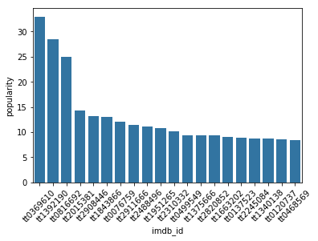

```python
pop_data = movie_data.sort_values('popularity',ascending = False).head(20)
base_color = sb.color_palette()[0]
sb.barplot(data = pop_data, x = 'imdb_id',y = 'popularity',color = base_color)
plt.xticks(rotation = 45)
```

**任务3.2：**分析电影净利润（票房-成本）随着年份变化的情况，并简单进行分析。

```
count    5.600000e+01
mean     4.889238e+09
std      5.149663e+09
min      2.718189e+07
25%      7.213913e+08
50%      2.783426e+09
75%      8.013349e+09
max      1.916590e+10
Name: profit, dtype: float64
```

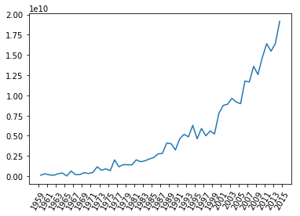

```python
profit_df = movie_data[['imdb_id','budget','revenue','release_year']]
profit_data = movie_data['revenue'] - movie_data['budget']
profit_df.insert(3,'profit',profit_data)


x_bins = np.arange(1959, 2016,1)
x_bin_centers = x_bins[:-1] +1/2

#ruled_bin = pd.cut(profit_df['profit'],x_bins,include_lowest = True)
profit_sum = profit_df.groupby('release_year')['profit'].sum()


plt.errorbar(data = profit_df, x = x_bin_centers, y = profit_sum)
plt.xticks(np.arange(1959,2016,step = 2),rotation = 60)
profit_sum.describe()
```

**[选做]任务3.3：**选择最多产的10位导演（电影数量最多的），绘制他们排行前3的三部电影的票房情况，并简要进行分析。

[output not shown]

**[选做]任务3.4：**分析1968年~2015年六月电影的数量的变化。

**[选做]任务3.5：**分析1968年~2015年六月电影 `Comedy` 和 `Drama` 两类电影的数量的变化。

> 注意: 当你写完了所有的代码，并且回答了所有的问题。你就可以把你的 iPython Notebook 导出成 HTML 文件。你可以在菜单栏，这样导出**File -> Download as -> HTML (.html)、Python (.py)** 把导出的 HTML、python文件 和这个 iPython notebook 一起提交给审阅者。